# Genoprobs QA/QC

Daniel Gatti

February 18, 2020

## Read in data

Load in the allele probs.

```r
aprobs = readRDS(file = file.path(hap_dir, "tufts_do_alleleprobs.rds"))
```

```r
# Read in the phenotypes.
pheno = readxl::read_xlsx(pheno_file)
pheno = pheno[,c('Mouse #', 'Coat color', 'Mouse strain', 'DOB or generation')]
colnames(pheno) = c('mouse', 'coat', 'strain', 'gen')
pheno$gen[pheno$gen == '41566'] = 'G16'
pheno$gen[pheno$gen == '41695'] = 'G17'
pheno$mouse = as.character(pheno$mouse)
```

## Founder allele probabilities for each sample.

Perform QC on the allele probs.

```r
fps = matrix(0.0, nrow(aprobs[[1]]), ncol(aprobs[[1]]))
for(p in aprobs) {
  fps = fps + apply(p, 1:2, sum)
} # for(p)
fps = fps / sum(sapply(aprobs, dim)[3,])

fps = cbind(fps, min = apply(fps, 1, min), max = apply(fps, 1, max))
write.csv(fps, file = file.path(base_dir, 'results', 'founder_freq_sample.csv'), quote = FALSE, row.names = FALSE)
```

Plot the founder allele frequencies for each sample.

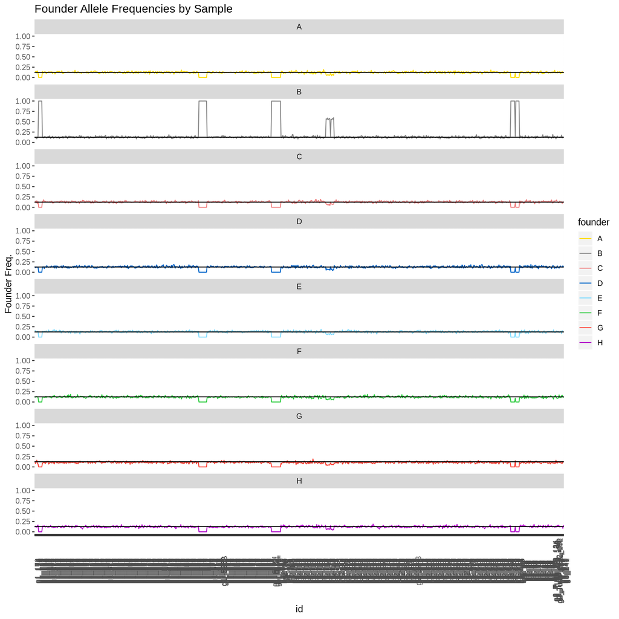

```r
cccolors2 = qtl2::CCcolors
names(cccolors2) = LETTERS[1:8]
data.frame(fps) %>%
  rownames_to_column(var = "id") %>%
  select(-min, -max) %>%
  gather(founder, freq, -id) %>%
  ggplot() +
  geom_line(aes(id, freq, color = founder, group = founder)) +
  geom_abline(aes(intercept = 0.125, slope = 0)) +
  scale_color_manual(values = cccolors2) +
  facet_wrap(~founder, nrow = 8) +
  theme(axis.text.x = element_text(angle = 90, vjust = 1)) +
  labs(title = "Founder Allele Frequencies by Sample", y = "Founder Freq.")
```

We can clearly see the C57BL/6J samples. Extract those and make sure that they’re the ones that we expect. There are also some BL6 F1s in here for some reason. Those might be Ron Korstaje’s samples.

Are the mice listed as C57BL/6J in the phenotype file all BL6?

```r
bl6_in_pheno = subset(pheno, grepl('C57BL', pheno$strain))
bl6_in_pheno$mouse = as.character(bl6_in_pheno$mouse)

fps_df = as.data.frame(fps) %>%
           rownames_to_column(var = 'id') %>%
           mutate(mouse = str_replace(id, '^g[0-9]_', ''))

bl6_pheno_fp = left_join(bl6_in_pheno, select(fps_df, id, B, mouse)) %>%
               arrange(mouse)
kable(bl6_pheno_fp, digits = 3)
```

| mouse | coat | strain | gen | id | B |
| --- | --- | --- | --- | --- | --- |
| 1089 | bl | C57BL/6J | NA | NA | NA |
| 1090 | bl | C57BL/6J | NA | NA | NA |
| 1090 | bl | C57BL/6J | NA | NA | NA |
| 1092 | bl | C57BL/6J | NA | NA | NA |
| 1093 | bl | C57BL/6J | NA | NA | NA |
| 1094 | bl | C57BL/6J | NA | NA | NA |
| 1095 | bl | C57BL/6J | NA | NA | NA |
| 1096 | bl | C57BL/6J | NA | NA | NA |
| 1097 | bl | C57BL/6J | NA | NA | NA |
| 1098 | bl | C57BL/6J | NA | NA | NA |
| 1099 | bl | C57BL/6J | NA | NA | NA |
| 1100 | bl | C57BL/6J | NA | NA | NA |
| 179 | bl | C57BL/6J | na | g1_179 | 0.999 |
| 179 | bl | C57BL/6J | na | g2_179 | 0.566 |
| 180 | bl | C57BL/6J | na | g1_180 | 0.999 |
| 180 | bl | C57BL/6J | na | g2_180 | 0.554 |
| 181 | bl | C57BL/6J | na | g1_181 | 0.999 |
| 181 | bl | C57BL/6J | na | g2_181 | 0.554 |
| 182 | bl | C57BL/6J | na | g1_182 | 0.999 |
| 182 | bl | C57BL/6J | na | g2_182 | 0.577 |
| 183 | bl | C57BL/6J | na | g1_183 | 0.999 |
| 183 | bl | C57BL/6J | na | g2_183 | 0.560 |
| 184 | bl | C57BL/6J | na | g1_184 | 0.999 |
| 184 | bl | C57BL/6J | na | g2_184 | 0.597 |
| 185 | bl | C57BL/6J | na | NA | NA |
| 186 | bl | C57BL/6J | na | NA | NA |
| 187 | bl | C57BL/6J | na | NA | NA |
| 188 | bl | C57BL/6J | na | NA | NA |
| 483 | bl | C57BL/6J | na | g1_483 | 1.000 |
| 483 | bl | C57BL/6J | na | g2_483 | 0.999 |

[output cut: 82 more lines]

NA means that the samples are not in the genotype data. This is OK because we don’t need to genotype BL6 mice. However, for samples 179 to 184, the group 1 samples are correct and the group 2 samples appear to be BL6 F1s.

Which mice are mostly BL6 in the founder probs, but aren’t listed as so in the phenotypes?

```r
bl6_in_fp = fps_df %>%
              select(id, B, mouse) %>%
              filter(B > 0.45) %>%
              mutate(mouse = str_replace(mouse, '\\.1$', '')) %>%
              arrange(mouse)

# Which
bl6_fp_pheno = left_join(bl6_in_fp, bl6_in_pheno)
kable(bl6_fp_pheno, digits = 3)
```

| id | B | mouse | coat | strain | gen |
| --- | --- | --- | --- | --- | --- |
| g2_173 | 0.568 | 173 | NA | NA | NA |
| g2_174 | 0.560 | 174 | NA | NA | NA |
| g2_175 | 0.589 | 175 | NA | NA | NA |
| g2_176 | 0.545 | 176 | NA | NA | NA |
| g2_177 | 0.559 | 177 | NA | NA | NA |
| g2_178 | 0.582 | 178 | NA | NA | NA |
| g1_179 | 0.999 | 179 | bl | C57BL/6J | na |
| g2_179 | 0.566 | 179 | bl | C57BL/6J | na |
| g1_180 | 0.999 | 180 | bl | C57BL/6J | na |
| g2_180 | 0.554 | 180 | bl | C57BL/6J | na |
| g1_181 | 0.999 | 181 | bl | C57BL/6J | na |
| g2_181 | 0.554 | 181 | bl | C57BL/6J | na |
| g1_182 | 0.999 | 182 | bl | C57BL/6J | na |
| g2_182 | 0.577 | 182 | bl | C57BL/6J | na |
| g1_183 | 0.999 | 183 | bl | C57BL/6J | na |
| g2_183 | 0.560 | 183 | bl | C57BL/6J | na |
| g1_184 | 0.999 | 184 | bl | C57BL/6J | na |
| g2_184 | 0.597 | 184 | bl | C57BL/6J | na |
| g1_483 | 1.000 | 483 | bl | C57BL/6J | na |
| g2_483 | 0.999 | 483 | bl | C57BL/6J | na |
| g1_484 | 1.000 | 484 | bl | C57BL/6J | na |
| g2_484 | 1.000 | 484 | bl | C57BL/6J | na |
| g1_485 | 1.000 | 485 | bl | C57BL/6J | na |
| g2_485 | 1.000 | 485 | bl | C57BL/6J | na |
| g1_486 | 1.000 | 486 | bl | C57BL/6J | na |
| g2_486 | 1.000 | 486 | bl | C57BL/6J | na |
| g1_487 | 1.000 | 487 | bl | C57BL/6J | na |
| g2_487 | 1.000 | 487 | bl | C57BL/6J | na |
| g1_488 | 1.000 | 488 | bl | C57BL/6J | na |
| g2_488 | 1.000 | 488 | bl | C57BL/6J | na |
| g1_489 | 1.000 | 489 | bl | C57BL/6J | na |
| g2_489 | 1.000 | 489 | bl | C57BL/6J | na |
| g1_490 | 1.000 | 490 | bl | C57BL/6J | na |
| g2_490 | 1.000 | 490 | bl | C57BL/6J | na |
| g1_491 | 1.000 | 491 | bl | C57BL/6J | na |
| g2_491 | 1.000 | 491 | bl | C57BL/6J | na |
| g1_492 | 1.000 | 492 | bl | C57BL/6J | na |
| g2_492 | 1.000 | 492 | bl | C57BL/6J | na |
| g1_493 | 1.000 | 493 | bl | C57BL/6J | na |
| g2_493 | 0.999 | 493 | bl | C57BL/6J | na |
| g1_494 | 0.999 | 494 | bl | C57BL/6J | na |
| g2_494 | 0.999 | 494 | bl | C57BL/6J | na |
| g1_495 | 0.998 | 495 | bl | C57BL/6J | na |
| g2_495 | 0.998 | 495 | bl | C57BL/6J | na |
| g1_612 | 0.997 | 612 | bl | C57BL/6J | na |
| g1_612.1 | 0.997 | 612 | bl | C57BL/6J | na |
| g1_613 | 0.997 | 613 | bl | C57BL/6J | na |
| g1_613.1 | 0.997 | 613 | bl | C57BL/6J | na |
| g1_614 | 0.997 | 614 | bl | C57BL/6J | na |
| g1_614.1 | 0.997 | 614 | bl | C57BL/6J | na |
| g1_615 | 0.997 | 615 | bl | C57BL/6J | na |
| g1_616 | 0.997 | 616 | bl | C57BL/6J | na |
| g1_617 | 0.997 | 617 | bl | C57BL/6J | na |
| g1_618 | 0.997 | 618 | bl | C57BL/6J | na |
| g1_619 | 0.996 | 619 | bl | C57BL/6J | na |
| g1_620 | 0.997 | 620 | bl | C57BL/6J | na |
| g1_621 | 0.997 | 621 | bl | C57BL/6J | na |
| g1_622 | 0.997 | 622 | bl | C57BL/6J | na |
| g1_623 | 0.997 | 623 | bl | C57BL/6J | na |

NA means that we don’t have these samples in phenotypes. I don’t see any DO mice in the list, so this is good.

I’m going to remove the mice that have BL6 contributions >= 0.45 from the founder probs.

```r
bl6_high = which(fps[,'B'] >= 0.45)
keep = setdiff(rownames(aprobs[[1]]), names(bl6_high))

for(i in seq_along(aprobs)) {
  aprobs[[i]] = aprobs[[i]][keep,,]
} # for(i)

fps = fps[keep,]
```

Plot the founder allele frequency distribution for each sample.

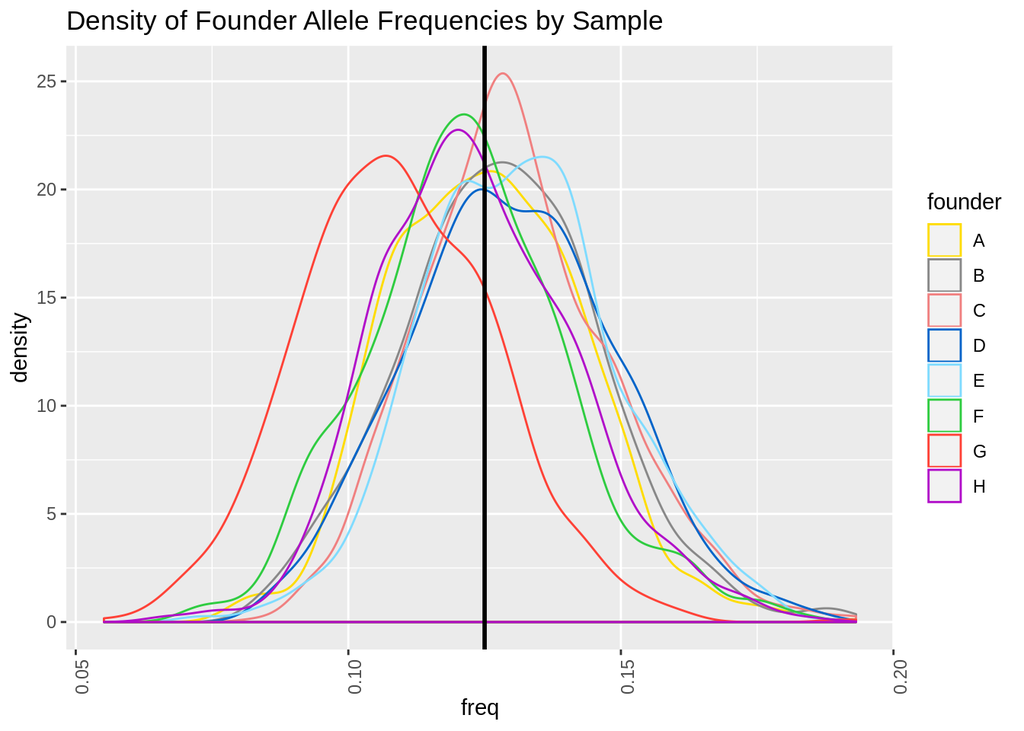

```r
data.frame(fps) %>%
  rownames_to_column(var = "id") %>%
  select(-min, -max) %>%
  gather(founder, freq, -id) %>%
  ggplot() +
  geom_density(aes(freq, color = founder)) +
  geom_vline(aes(xintercept = 0.125), size = 1) +
  scale_color_manual(values = cccolors2) +
  theme(axis.text.x = element_text(angle = 90, vjust = 1)) +
  labs(title = "Density of Founder Allele Frequencies by Sample")
```

PWK (in red) is known to have a lower allele frequency than the other founders. The black line in the center is the 1/8th (0.125) line.

## Founder Allele Probabilities along Chromosomes

Look at the founder allele frequencies along each chromosome.

```r
fpc = vector("list", length(aprobs))
names(fpc) = names(aprobs)
for(p in seq_along(aprobs)) {
  fpc[[p]] = apply(aprobs[[p]], 2:3, mean)
} # for(p)

tmp = t(fpc[[1]])
for(p in 2:length(fpc)) {
  tmp = rbind(tmp, t(fpc[[p]]))
} # for(p)
fpc = tmp
rm(tmp)

write.csv(fpc, file = file.path(base_dir, "results', 'founder_freq_marker.csv"), quote = FALSE, row.names = FALSE)
```

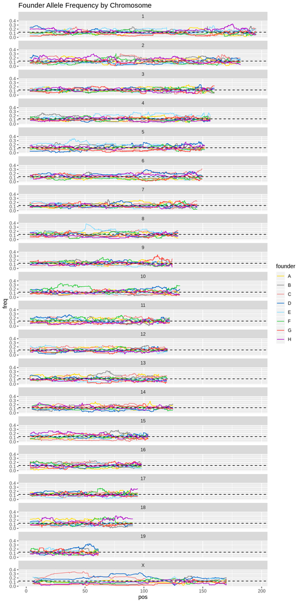

```r
markers = readr::read_csv(file.path(muga_dir, 'gm_uwisc_v1.csv'), col_types = 'ccnnncclllnnc') %>%
            select(marker, chr, pos = bp_mm10)
data.frame(fpc) %>%
  rownames_to_column(var = "marker") %>%
  inner_join(y = select(markers, chr, marker, pos)) %>%
  mutate(pos = pos * 1e-6,
         chr = factor(chr, levels = c(1:19, 'X'))) %>%
  gather(founder, freq, -marker, -chr, -pos) %>%
  ggplot() +
  geom_line(aes(pos, freq, color = founder)) +
  geom_hline(aes(yintercept = 0.125), linetype = 2) +
  scale_color_manual(values = cccolors2) +
  facet_wrap(~chr, ncol = 1) +
  labs(title = "Founder Allele Frequency by Chromosome")
```

Some of the allele frequencies are quite high. On Chr X, 129S1 and NOD are high while WSB and PWK are low. PWK is somewhat expected.

## Number of Recombinations per Sample.

```r
cross = qtl2::read_cross2(file = file.path(hap_dir, "qtl2/tufts.json"), quiet = FALSE)
```

```
##  - reading geno
```

```
##  - encoding geno
```

```
##  - reading gmap
```

```
##  - reading pmap
```

```
##  - reading pheno
```

```
##  - reading covar
```

```
##  - reading founder_geno
```

```
##  - encoding founder_geno
```

```
##  - splitting up gmap
```

```
##  - splitting up pmap
```

```
##  - splitting up geno
```

```
##  - splitting up founder_geno
```

```r
cross = cross[keep,]
vit = qtl2:::viterbi2(cross = cross, quiet = FALSE, cores = 8)
```

```
##  - Using 8 cores
```

```r
saveRDS(vit, file = file.path(base_dir, "results/viterbi.rds"))

num_recomb = rep(0, nrow(vit[[1]]))
names(num_recomb) = rownames(vit[[1]])

for(v in vit) {
  vdiff = abs(diff(t(v)))
  num_recomb = num_recomb + colSums(vdiff > 0)
} # for(v)

num_recomb = data.frame(num_recomb) %>%
               rownames_to_column(var = "id")
```

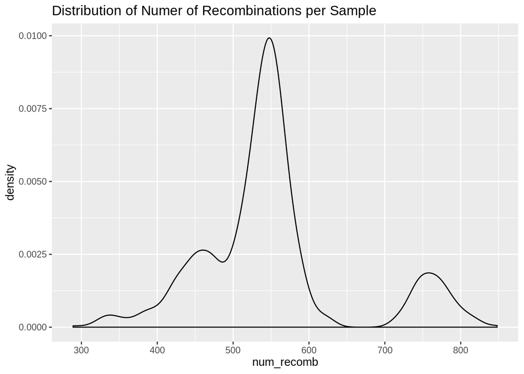

```r
num_recomb %>%
  ggplot() +
  geom_density(aes(num_recomb)) +
  labs(title = "Distribution of Numer of Recombinations per Sample")
```

Plot the number of recombinations per sample by generation. We don’t have generation data for the last set of mice yet.

```r
num_recomb = num_recomb %>%
               mutate(mouse = str_replace(id, '^g[0-9]_', '')) %>%
               mutate(mouse = str_replace(mouse, '^Tufts_GB(2)?_', '')) %>%
               left_join(pheno)
```

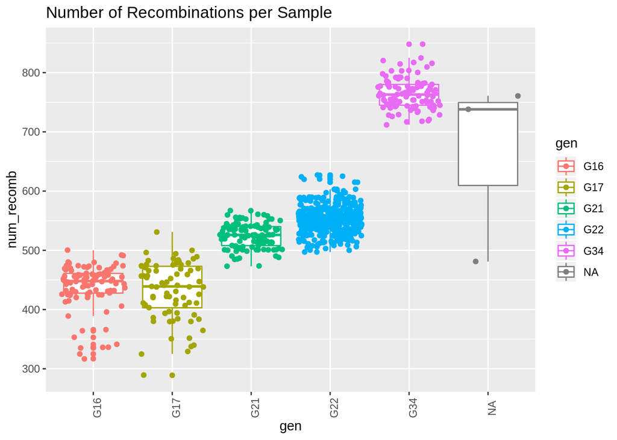

```r
num_recomb %>%
  ggplot() +
  geom_boxplot(aes(gen, num_recomb, color = gen)) +
  geom_jitter(aes(gen, num_recomb, color = gen)) +
  labs(title = "Number of Recombinations per Sample") +
  theme(axis.text.x = element_text(angle = 90, vjust = 1))
```

Look at those low-recombination samples in the NA group.

```r
num_recomb %>%
  filter(is.na(gen) & num_recomb < 600)
```

```
##        id num_recomb mouse coat strain  gen
## 1 g2_32_3        481  32_3 <NA>   <NA> <NA>
```

This is an unknown sample.

## Genotyping Replicates

Some of these are the exact same data run through the haplotype reconstruction twice.

```r
dupl = data.frame(id = rownames(aprobs[[1]])) %>%
          mutate(mouse = str_replace(id, '^g[0-9]_', ''),
                 mouse = str_replace(mouse, '^Tufts_GB(2)?_', '')) %>%
          group_by(mouse) %>%
          filter(n() > 1) %>%
          arrange(mouse)

dupl_cor = matrix(0, nrow = nrow(dupl), ncol = nrow(dupl),
                  dimnames = list(dupl$id, dupl$id))

for(i in seq_along(aprobs)) {

  print(paste('chr', i))

  tmp = aprobs[[i]][dupl$id,,]

  for(j in 1:dim(tmp)[3]) {
    dupl_cor = dupl_cor + cor(t(tmp[,,j]))
  } # for(j)

} # for(i)
```

```
## [1] "chr 1"
## [1] "chr 2"
## [1] "chr 3"
## [1] "chr 4"
## [1] "chr 5"
## [1] "chr 6"
## [1] "chr 7"
## [1] "chr 8"
## [1] "chr 9"
## [1] "chr 10"
## [1] "chr 11"
## [1] "chr 12"
## [1] "chr 13"
## [1] "chr 14"
## [1] "chr 15"
## [1] "chr 16"
## [1] "chr 17"
## [1] "chr 18"
## [1] "chr 19"
## [1] "chr 20"
```

```r
dupl_cor = dupl_cor / rowSums(sapply(aprobs, dim))[3]
```

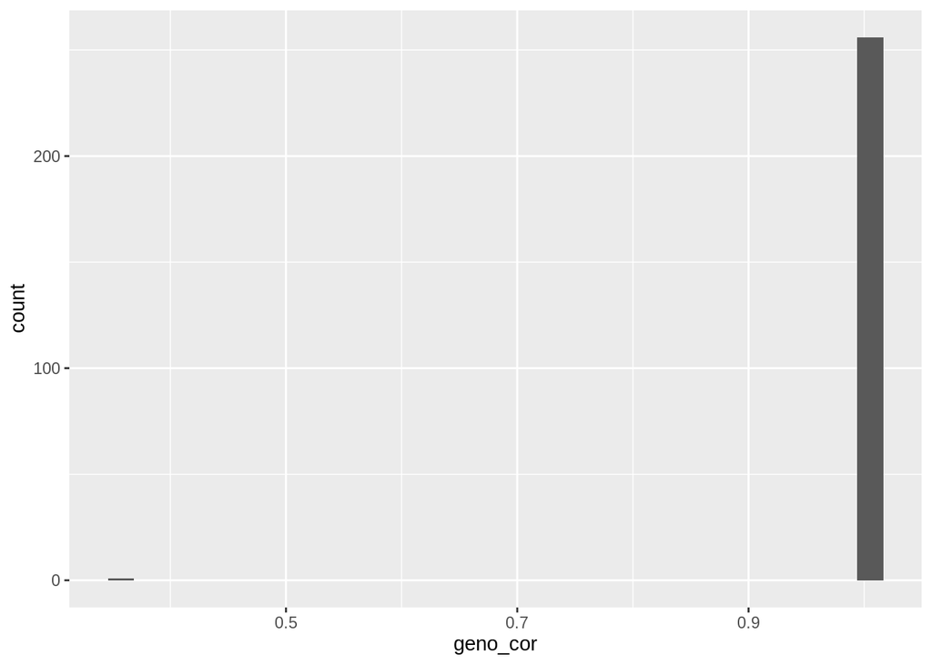

```r
dupl_samples = data.frame(mouse = unique(dupl$mouse),
                          geno_cor = 0)

for(i in 1:nrow(dupl_samples)) {

  ids = dupl$id[dupl$mouse == dupl_samples$mouse[i]]
  dupl_samples$geno_cor[i] = mean(dupl_cor[ids,ids][lower.tri(dupl_cor[ids,ids])])

} # for(i)

ggplot(dupl_samples) +
  geom_histogram(aes(geno_cor))
```

There is one mouse with poor duplication.

```r
filter(dupl_samples, geno_cor < 0.9)
```

```
##   mouse  geno_cor
## 1   230 0.3522123
```

For most of the samples, we can use either run. But for sample 230, we need to select one of the replicates or discard the sample completely.

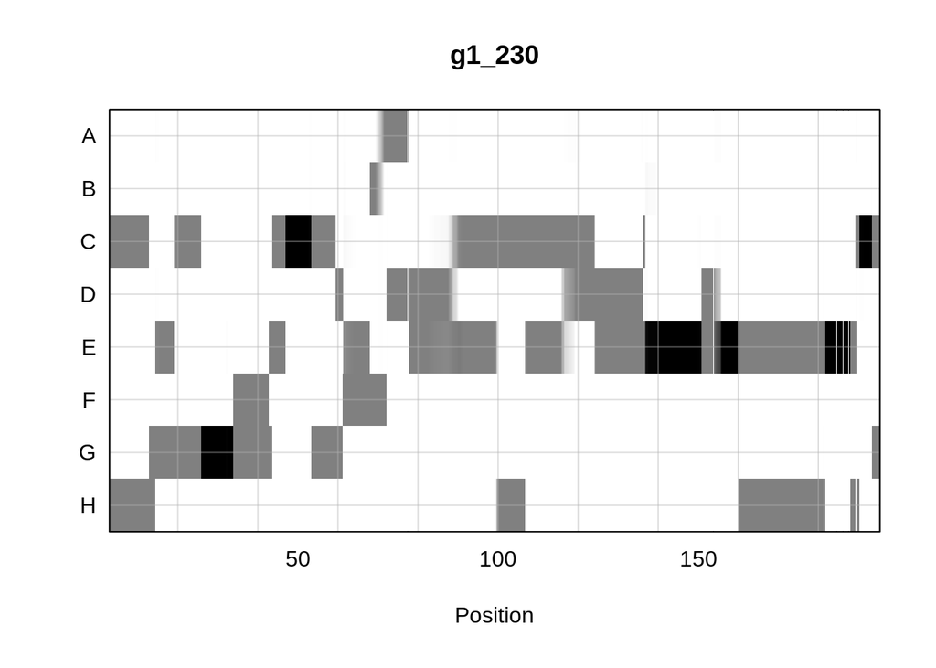

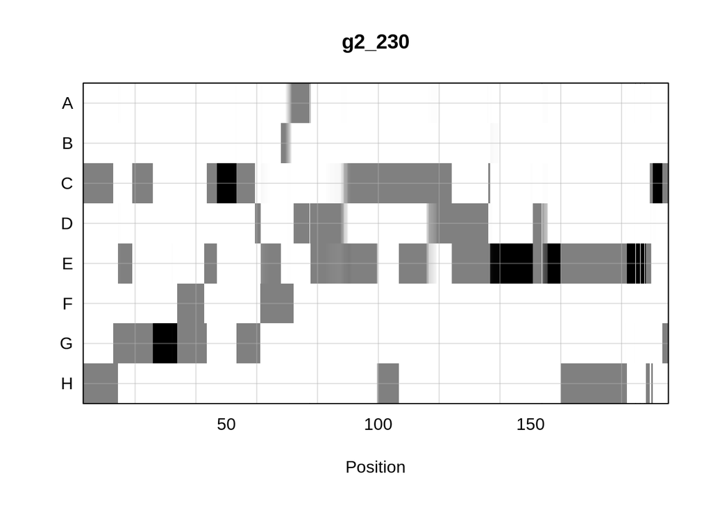

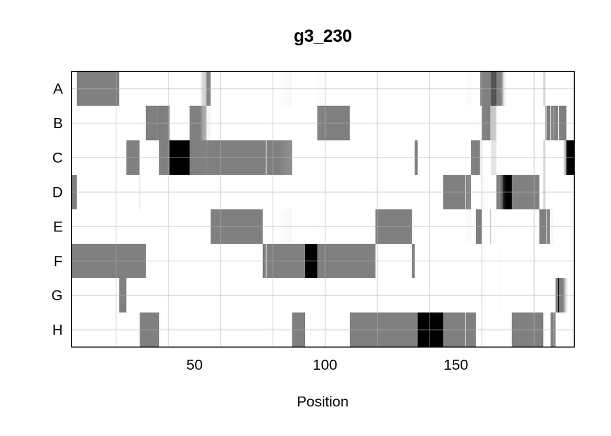

```r
sample_230_ids = filter(dupl, mouse == 230)
for(i in 1:nrow(sample_230_ids)) {
   qtl2::plot_genoprob(aprobs[sample_230_ids$id[i],], map = cross$pmap, main = sample_230_ids$id[i])
}
```

The run from G3 is off. But the other two runs are probably from the same data. I can’t tell which one is correct right now.

## Coat Color Checks

The Albino locus is on Chr 7 at 87.42 - 87.49 Mb (Tyr) and the Agouti locus is on Chr 2 at 154.79 - 155.05 Mb (a). Mice carrying the A and D alleles at the albino locus will be albino. Mice carrying the A or B alleles on Chr 2 that aren’t albino will be black. We can compare the coat color in the phenotype data with the founder allele at the albino locus to determine if there has been a sample mixup.

Remove the C57BL/6J mice and change the coat colors to wh, br & bl.

```r
pheno = subset(pheno, !grepl('C57BL/6J', coat))
pheno = pheno %>%
          mutate(coat = if_else(coat == 'w', 'wh', coat),
                 coat = str_replace(coat, 'w/( )?wh belly( & tail tio)?$', ''),
                 coat = str_replace(coat, 'w/wh (head spot|tail tip)$', ''),
                 coat = str_replace(coat, '^lt ', ''),
                 coat = str_replace(coat, '\\+wh head spot$', ''),
                 coat = str_trim(coat))
count(pheno, coat)
```

```
## # A tibble: 5 x 2
##   coat      n
##   <chr> <int>
## 1 22.4      1
## 2 bl      186
## 3 br      495
## 4 wh      178
## 5 <NA>    220
```

Get the founder allele calls on Chr 7 near the Tyr locus.

```r
# Markers near Tyr gene.
tyr_mkr = subset(markers, chr == '7' & pos >= 87400000 & pos <= 87500000)
tyr_mkr = tyr_mkr[tyr_mkr$marker %in% dimnames(aprobs[[7]])[[3]],]
a_mkr   = subset(markers, chr == '2' & pos >= 154790000 & pos <= 155100000)
a_mkr   = a_mkr[a_mkr$marker %in% dimnames(aprobs[[2]])[[3]],]
# Get the probs for the agouti locus.
pr_2 = aprobs[[2]][,,a_mkr$marker]
# Get the probs for the albino locus.
pr_7 = aprobs[[7]][,,tyr_mkr$marker]

samples = sub('^g[0-9]_', '', rownames(pr_7))
samples = sub('^Tufts_GB(2)?_', '', samples)

# For each sample, list the sample ID, listed coat color, prob of A/D and A/B genotypes.
samples = data.frame(geno_id = rownames(pr_7), sample = samples, coat = NA, prob_AD = NA, prob_AB = NA, remove = F)

for(i in 1:nrow(samples)) {

  # Get the phenotype row for this sample.
  pheno_wh = which(pheno$mouse == samples$sample[i])

  # If the sample was found, match up coat color with genotype probs.
  if(length(pheno_wh) > 0) {
    # Assing coat color.
    samples$coat[i] = pheno$coat[pheno_wh]
    # Assign A/D prob.
    samples$prob_AD[i] = sum(rowMeans(pr_7[i,,])[c('A', 'D')])
    # Assign A/B prob.
    samples$prob_AB[i] = sum(rowMeans(pr_2[i,,])[c('A', 'B')])
  } # if(length(wh) > 0)

} # for(i)
```

Which samples were listed as having a white coat in the phenotype file but don’t have an AA, AD or DD genotype?

```r
filter(samples, coat == 'wh' & prob_AD < 0.9)
```

```
##   geno_id sample coat      prob_AD   prob_AB remove
## 1  g1_375    375   wh 6.826633e-08 0.4999993  FALSE
## 2  g1_404    404   wh 3.381823e-07 0.4999993  FALSE
## 3  g1_603    603   wh 4.999988e-01 0.9999977  FALSE
## 4  g2_375    375   wh 6.826633e-08 0.4999993  FALSE
## 5  g2_404    404   wh 3.381823e-07 0.4999993  FALSE
```

Three samples: 375, 404 & 603.

Which samples have AA, AD or DD genotypes but aren’t listed as ‘white’ in the phenotype file?

```r
filter(samples, coat != 'wh' & prob_AD > 0.9)
```

```
##   geno_id sample coat   prob_AD   prob_AB remove
## 1  g1_405    405   br 0.9999422 0.4999990  FALSE
## 2  g1_605    605   bl 0.9999972 0.9999977  FALSE
## 3  g2_405    405   br 0.9999422 0.4999990  FALSE
## 4  g3_230    230   br 0.9999955 0.4999991  FALSE
```

Three samples: 230, 405 & 605.

Which samples were listed as having a black coat in the phenotype file but don’t have an AA, AB or BB genotype?

```r
filter(samples, coat == 'bl' & prob_AB < 0.9)
```

```
##   geno_id sample coat  prob_AD      prob_AB remove
## 1  g1_333    333   bl 0.499999 7.287186e-07  FALSE
## 2  g2_333    333   bl 0.499999 7.287186e-07  FALSE
```

One sample: 333.

Which samples have AA, AB or BB genotypes and are not albino but aren’t listed as ‘black’ in the phenotype file?

```r
filter(samples, coat != 'bl' & prob_AB > 0.9 & prob_AD < 0.9)
```

```
##   geno_id sample coat      prob_AD   prob_AB remove
## 1  g1_332    332   br 5.969637e-07 0.9999979  FALSE
## 2  g1_514    514   br 4.999988e-01 0.9999977  FALSE
## 3  g1_603    603   wh 4.999988e-01 0.9999977  FALSE
## 4  g2_332    332   br 5.969637e-07 0.9999979  FALSE
```

Three samples: 332, 514, 603.

For 230, the sample in batch 3 differs from the other batches and does not have the correct coat color. I will remove that sample. Samples 375 and 514 do not have the correct coat color. I will remove them.

```r
remove = c('g3_230', 'g1_375', 'g2_375', 'g1_514')
for(i in seq_along(aprobs)) {
  aprobs[[i]] = aprobs[[i]][!rownames(aprobs[[i]]) %in% remove,,]
} # for(i)
```

Samples 332 & 333, 404 & 405, and 603 and 605 may have been swapped. I will swap them in the genotype data.

```r
swap = data.frame(old = c('g1_332', 'g1_333', 'g2_333', 'g1_404', 'g2_404', 'g1_405', 'g1_603', 'g1_605'),
                  new = c('g1_333', 'g1_332', 'g2_332', 'g1_405', 'g2_405', 'g1_404', 'g1_605', 'g1_603'))
rn = rownames(aprobs[[1]])
wh = match(swap$old, rn)
rn[wh] = swap$new

for(i in seq_along(aprobs)) {
  rownames(aprobs[[i]]) = rn
} # for(i)
```

## Remove Duplicates

Keep only unique samples and write out the cleaned founder allele probs.

```r
samples = data.frame(geno_id = rownames(aprobs[[1]]),
                     sample  = NA,
                     dupl    = F)
samples$sample = sub('^g[0-9]_',       '', samples$geno_id)
samples$sample = sub('^Tufts_GB(2)?_', '', samples$sample)
samples$dupl = duplicated(samples$sample)
keep = which(!samples$dupl)

for(i in seq_along(aprobs)) {

  aprobs[[i]] = aprobs[[i]][keep,,]
  rownames(aprobs[[i]]) = samples$sample[keep]

} # for(i)
```

Dimensions of allele probs. Each element represents one chromosome with dimensions of samples, by founders by markers.

```r
sapply(aprobs, dim)
```

```
##         1    2    3    4    5    6    7    8    9   10   11   12   13   14   15
## [1,]  526  526  526  526  526  526  526  526  526  526  526  526  526  526  526
## [2,]    8    8    8    8    8    8    8    8    8    8    8    8    8    8    8
## [3,] 9159 9236 7020 7007 6945 6899 6692 6002 6171 5835 6602 5478 5611 5451 4894
##        16   17   18   19    X
## [1,]  526  526  526  526  526
## [2,]    8    8    8    8    8
## [3,] 4612 4545 4235 3289 4198
```

Write out the cleaned founder allele probs.

```r
saveRDS(aprobs, file = file.path(hap_dir, 'tufts_do_alleleprobs_cleaned.rds'))
```